# Marketing report part 3

Authors

Ana de Armas

Luis Francisco Gomez

Published

November 30, 2024

# 1 Modeling

## 1.2 Import data

```r
# Import the data from the sweep package
bike_sales <- bike_sales |>
  mutate(order.id           = factor(x = order.id,
                                     ordered = FALSE),
         order.line         = factor(x = order.id,
                                     ordered = TRUE),
         customer.id        = factor(x = customer.id,
                                     ordered = FALSE),
         bikeshop.name      = factor(x = bikeshop.name,
                                     ordered = FALSE),
         bikeshop.city      = factor(x = bikeshop.city,
                                ordered = FALSE),
         bikeshop.state     = factor(x = bikeshop.state,
                                     ordered = FALSE),
         product.id         = factor(x = product.id,
                                     ordered = FALSE),
         model              = factor(x = model,
                                     ordered = FALSE),
         category.primary   = factor(x = category.primary ,
                                     ordered = FALSE),
         category.secondary = factor(x = category.secondary,
                                     ordered = FALSE),
         frame              = factor(x = frame,
                                     ordered = FALSE))
```

## 1.3 The product gap

Use the available functions from the `tidyverse` to create a visualization so the Research and Development (R & D) division can understand the [product gap](https://en.wikipedia.org/wiki/Gap_analysis)

Brake the process in 2 steps:

- Prepare the data
  - You can use `select`, `group_by`, `summarise`, `ungroup`, `arrange`, `mutate` and `fct_reorder`

```r
# Use bike_sales to calculate the total revenue
# grouped by model, category.secondary and frame

## You can proceed in the following way
### This is only a template you can modify the code
### if you want to add or apply another way to
### prepare the data
#### Remember to load the tidyverse library: library(tidyverse)

# total_sales_by_model_second_category_frame <- bike_sales |>
#   select(model, category.secondary, frame, price.ext) |>
#   group_by(model, category.secondary, frame) |>
#   summarise(total_revenue = sum(price.ext)) |>
#   ungroup() |>
#   arrange(desc(total_revenue)) |>
#   mutate(category.secondary = fct_reorder(.f = category.secondary,
#                                           .x = total_revenue))
#
# total_sales_by_model_second_category_frame

## Prepare data ----
total_sales_by_cat2_frame_model <- bike_sales |>
  group_by(model, category.secondary, frame) |>
  summarize(total_sales = sum(price.ext)) |>
  ungroup() |>
  arrange(desc(total_sales)) |>
  mutate(category.secondary = fct_reorder(.f = category.secondary,
                                          .x = total_sales))
```

- Generate an informative plot
  - You can use `ggplot`, `geom_point`, `position_jitter`, `scale_y_continuous`, `scales::label_dollar` and `facet_wrap`
  - You can also use `labs` to personalize the labels of the x-axis, y-axis and title and change the colors if you want

Using `facet_wrap` you can identify which combinations between `category.secondary` and `frame` are empty without data where they correspond to the [product gap](https://en.wikipedia.org/wiki/Gap_analysis)

Also check out the combinations that you reported in the first marketing report to verify that your plot is reflecting this aspect

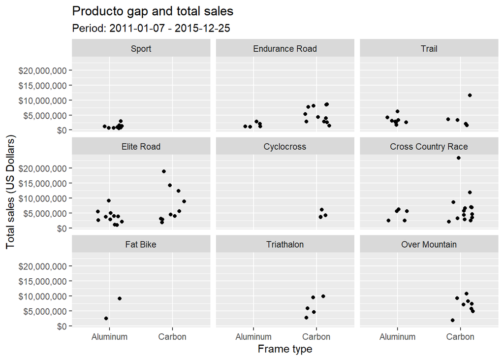

```r
# You can visualize the product gap by generating
# group visualizations by category.secondary
# when inspecting the relation between frame and
# total revenue

## You can proceed in the following way
### This is only a template you can modify the code
### if you want to add or apply another way to
### visualize the data or personalize the plot

# total_sales_by_model_second_category_frame |>
#   ggplot() +
#   geom_point(aes(x = frame, y = total_revenue),
#              position = position_jitter(width = 0.2,
#                                         height = 0.2)) +
#   scale_y_continuous(labels = scales::label_dollar()) +
#   facet_wrap(facets = vars(category.secondary))

## Creating the plot ----
total_sales_by_cat2_frame_model |>
  ggplot() +
  geom_point(aes(x = frame, y = total_sales),
             position = position_jitter(width  = 0.2,
                                        height = 0.2)) +
  scale_y_continuous(labels = label_dollar()) +
  facet_wrap(facets = vars(category.secondary)) +
  labs(x = "Frame type",
       y = "Total sales (US Dollars)",
       title = "Producto gap and total sales",
       subtitle = "Period: 2011-01-07 - 2015-12-25")
```

## 1.4 Determine the price of a new product

### 1.4.1 Selecting a new potential product

Once you have identify the combination of categories that belong to the product gap please choose a product that is not offer by the corporation so the Research and Development (R & D) division can develop it

According to the results of the first marketing report remember that the categories that belong to the product gap are:

- Cyclocross Aluminum
- Fat Bike Carbon
- Over Mountain Aluminum
- Sport Carbon
- Triathalon Aluminum

Taking into account that it is difficult for the Research and Development (R & D) division to develop 5 new products please recommend this division a new product to develop by pointing out a sound reason based on you marketing expertise

### 1.4.2 Building a model to price a new product

Once you have choose the new product you want to recommend to the Research and Development (R & D) division in this section you are going to determine the price of this new product using similar products already offer by the corporation

#### 1.4.2.1 Choosing a model

Using the results developed in the second marketing report in relation to the **Analysis of Variance (ANOVA)** section choose a model that you consider appropiate.

Recall that you explored the following models, which are organized by level of complexity from the lowest to the highest:

- `price ~ category.secondary`
- `price ~ category.secondary + frame`
- `price ~ category.secondary*frame`
- `price ~ category.secondary*frame*bikeshop.state`

**Note 1**: If the model is to complex like `price ~ category.secondary*frame*bikeshop.state` you will obtain a considerable parameters but if the model is to simple like `price ~ category.secondary` you will not be able to obtain good predictions. Choose the level of complexity that you consider appropriate to help the Research and Development (R & D) division and to determine the new price of the new product

**Note 2**: If you find that the model generates silly results, like for example negative or 0 values for the price, abandon the choosen model and use another model or change the product gap combination or discard particular locations where the product will going to be offer.

#### 1.4.2.2 Fit the model

One you have choose the model, fit it using the function `lm` and explore the results of the model with the `tidy` function from the `tidymodels` library:

```r
# For example if you choose the model
# price ~ category.secondary*frame*bikeshop.state
# you will fit the following model
## Remember to load the tidymodels library: library(tidymodels)

# model <- lm(formula = price ~ category.secondary*frame*bikeshop.state,
#             data = bike_sales)
#
# model |> tidy()
model2 <- lm(formula = price ~ category.secondary*frame,
             data = bike_sales)

model2_tidy <- model2 |> tidy()

model2_tidy |>
  datatable() |>
  formatRound(columns = c("estimate",
                          "std.error",
                          "statistic",
                          "p.value"),
              digits = 4)
```

|  | term | estimate | std.error | statistic | p.value |
| --- | --- | --- | --- | --- | --- |
| 1 | (Intercept) | 2553.647294589562 | 60.69817517072705 | 42.0712366954503 | 0 |
| 2 | category.secondaryCyclocross | -4388.207597748164 | 86.53072655190037 | -50.71270949188385 | 0 |
| 3 | category.secondaryElite Road | -321.9959889055755 | 74.61207493877352 | -4.315601585531627 | 1.601471613566273e-05 |
| 4 | category.secondaryEndurance Road | -1193.222666138901 | 87.1065971524913 | -13.69841900780501 | 1.824943614558298e-42 |
| 5 | category.secondaryFat Bike | 213.0873992878574 | 127.2428026381146 | 1.674651884978434 | 0.09402255743075891 |
| 6 | category.secondaryOver Mountain | -1722.266622556879 | 71.61398787544476 | -24.04930480274812 | 1.601335973040712e-125 |
| 7 | category.secondarySport | -1660.037154729301 | 76.33468443122088 | -21.74682671577726 | 2.504645123380833e-103 |
| 8 | category.secondaryTrail | -87.6417274356214 | 79.01266920140685 | -1.109211071103277 | 0.2673562026795321 |
| 9 | category.secondaryTriathalon | -3200.334244110589 | 78.89341628831325 | -40.56528915435831 | 0 |
| 10 | frameCarbon | 4173.272878010336 | 75.28275958618437 | 55.43464268512549 | 0 |

[output cut: 8 more lines]

#### 1.4.2.3 Predict the price of the new product

Once you fit the model and taking into account the selected new potential product predict the new price for the new product

Remember to create a tibble or data frame with the new data you want to predict

In this part you can use the functions `predict`, `enframe` and `bind_cols` to present your results in an organized way

```r
# For example if you choose the model
# price ~ category.secondary*frame*bikeshop.state
# and the new product to develop as Cyclocross Aluminium
# you proceed in the following way

## In this case because the model
## price ~ category.secondary*frame*bikeshop.state
## include the bikeshop.state you need to select at least
## one state to make predictions

### Lets predict the price for 3 states and the combination
### Triathalon Aluminum:
#### "AZ": Arizona
#### "CA": California
#### "CO": Colorado
#### category.secondary = "Triathalon"
#### frame = "Aluminum"

# new_data <- tibble(category.secondary = c("Triathalon", "Triathalon", "Triathalon"),
#                    frame = c("Aluminum", "Aluminum", "Aluminum"),
#                    bikeshop.state = c("AZ", "CA", "CO"))
#
# predict(object = model, newdata = new_data) |>
#   enframe(name = "observation", value = "price_prediction") |>
#   bind_cols(new_data)

### If you check this example you will get
#   observation price_prediction category.secondary frame    bikeshop.state
#   <chr>                  <dbl> <chr>              <chr>    <chr>
# 1 1                     -705.  Triathalon         Aluminum AZ
# 2 2                       95.8 Triathalon         Aluminum CA
# 3 3                    -1157.  Triathalon         Aluminum CO

#### In this case it only make sense to offer this product in California (CA)
#### In the remaining states, the product is not worth offering. In such cases
#### you would have to give it free to the public.

## Price predictions ----
new_data <- tibble(category.secondary = c("Fat Bike", "Over Mountain"),
                   frame              = c("Carbon"  , "Aluminum"))

predictions <- predict(object = model2,
                       newdata = new_data) |>
  enframe(name = "observation", value = "price_prediction") |>
  bind_cols(new_data) |>
  arrange(desc(price_prediction))

predictions |>
  datatable() |>
  formatRound(columns = c("price_prediction"))
```

|  | observation | price_prediction | category.secondary | frame |
| --- | --- | --- | --- | --- |
| 1 | 1 | 6940.007571887755 | Fat Bike | Carbon |
| 2 | 2 | 831.3806720326822 | Over Mountain | Aluminum |

## 1.5 Segment bike shops with k-means clustering

### 1.5.1 Bike shop revenue trends

In this section the objective is to group and aggregate data to calculate the total revenue using the variable `price.ext`

- Select the variables `bikeshop.name`, `price.ext`, `model`, `category.primary`, `category.secondary` and `frame`
- Group the data by `bikeshop.name`, `model`, `category.primary`, `category.secondary` and `frame`
- Calculate the total revenue and ungroup the data using the `ungroup` function or the `.groups = "drop"` argument from `summarise`

```r
# In this part you can use the functions
# select, group_by and summarise
## You can use at the end ungroup of
## the argument .groups = "drop" to
## ungroup the data
### If you name the variable as total_revenue the first 5 rows
### and the first and last column of the  final data will be:

# # A tibble: 5 × 2
#   bikeshop.name      total_revenue
#   <chr>                      <dbl>
# 1 Albuquerque Cycles         92800
# 2 Albuquerque Cycles          5320
# 3 Albuquerque Cycles          8310
# 4 Albuquerque Cycles         19170
# 5 Albuquerque Cycles          1620

### Remember that you will get 6 columns but I am only showing
### 2 columns of the data
bikeshop_sales_total_revenue <- bike_sales |>
  select(bikeshop.name,
         price.ext,
         model,
         category.primary,
         category.secondary,
         frame) |>
  group_by(bikeshop.name,
           model,
           category.primary,
           category.secondary,
           frame) |>
  summarise(total_revenue = sum(price.ext)) |>
  ungroup()
```

### 1.5.2 Prepare data

The objective of this part is to:

- Normalize the data so you can apply latter the **principal component analysis** dimensionality reduction technique
- Create a customer-product table with a column that includes all the bikeshops and the rest of the columns with information about the percentage of total revenue of the **97** models offered by the corporation and described in the variable `model`

#### 1.5.2.1 Normalization

```r
# Follow this template to normalize the data

# bike_sales_total_revenue_pct <- bike_sales_total_revenue |>
#   group_by(bikeshop.name) |>
#   mutate(total_revenue_pct = total_revenue / sum(total_revenue)) |>
#   ungroup()

## You can check the data using
### bike_sales_total_revenue_pct |> glimpse()
bikeshop_sales_total_revenue_pct <- bikeshop_sales_total_revenue |>
  group_by(bikeshop.name) |>
  mutate(total_revenue_pct = total_revenue / sum(total_revenue)) |>
  ungroup()
```

#### 1.5.2.2 Customer-product table

In this part you are going to use the function `pivot_wider` to create the customer-product table. For more information checkout `?pivot_wider`

Also check out the argument `values_fill` from this function and try this function with and without this argument so you can understand why it is important to use `values_fill = 0`

```r
# Follow this template to create a customer-product table

# customer_product_table <- bike_sales_total_revenue_pct |>
#   select(bikeshop.name,
#          model,
#          total_revenue_pct) |>
#   pivot_wider(id_cols = bikeshop.name,
#               names_from = model,
#               values_from = total_revenue_pct,
#               values_fill = 0)

## You can check the data using
### bike_sales_total_revenue_pct |> glimpse()

#### A particular cell of the data will correspond to
#### the percentage revenue generated by a model and a
#### bike shop
#### For example if the row and the column corresponds to
##### bikeshop.name = Albuquerque Cycles
##### `Bad Habit 1` = 0.00571
#### It will mean that this model has a participation
#### in the total revenue generated by Albuquerque
#### Cycles of 0.571 %
customer_product_table <- bikeshop_sales_total_revenue_pct |>
  select(bikeshop.name, model, total_revenue_pct) |>
  pivot_wider(id_cols = bikeshop.name,
              names_from = model,
              values_from = total_revenue_pct,
              values_fill = 0)
```

### 1.5.3 Performing k-means clustering

The objective of this section is to apply the k-means clustering technique by grouping the bike shops in **5** clusters

- If you want you can try with a different number of clusters but first it is important that you at least be able to complete the task with **5** clusters

Use the `kmeans` function with the argument `centers = 5` and applying it to the customer product table

- Remember that `kmeans` only works with numerical data so you will need to drop the `bikeshop.name` from the customer product table
  - Checkout `?kmeans` and the argument `x` in relation to this aspect
- Once you have apply the k-means clustering technique save this object as `kmeans_object`

#### 1.5.3.1 Extracting the cluster assignment

Now that you have apply the k-means clustering technique you are going to extract the clusters and assign them to each bike shop

```r
# Follow this template to obtain the relevant information
# required by the marketing team

# clusters <- kmeans_object |>
#   augment(data = customer_product_table) |>
#   select(bikeshop.name, .cluster)

## You can check the data using
### clusters |> glimpse()
### clusters |> count(.cluster)
set.seed(seed = 1234)
kmeans_object <- customer_product_table |>
  select(-bikeshop.name) |>
  kmeans(centers = 5,
         algorithm = "Hartigan-Wong")

clusters <- kmeans_object$cluster
```

### 1.5.4 Data visualization with k-means clustering and principal component analysis

It is difficult to visualize the clusters that are identified using `kmeans` taking into account that in our case we use **97** variables (the participation of the total revenue of the **97** models) and a human being can not visualize a plot 97 dimensional plot

In this section you are going to reduce the data complexity by generating a 2 dimensional projection of the **97** variables by applying the principal component analysis technique

Use the `prcomp` function with the argument `center = TRUE` and applying it to the customer product table

- Remember that `prcomp` only works with numerical data so you will need to drop the `bikeshop.name` from the customer product table
  - Checkout `?prcomp` and the argument `x` in relation to this aspect
- Also take into account that you don’t need to scale the data using the argument `scale. = TRUE` because each data point from the customer product table corresponds to the participation of the total revenue of each model generated by each bike shop
- Once you have apply the principal component analysis technique save this object as `pca_object`

#### 1.5.4.1 Extracting the first 2 principal components

In this section you are going to extract the first 2 principal components so you can use them to visualize the clusters in a 2 dimensional plot

```r
# Follow this template to obtain the first 2
# principal components

# pca_1_2 <- pca_object$x |>
#   as_tibble() |>
#   select(PC1, PC2)

## Name this object as pca_1_2 so you will remember
## that it contains the first 2 principal components

## You can check the data using
### pca_1_2 |> glimpse()
pca_object <- customer_product_table |>
  select(-bikeshop.name) |>
  prcomp(center = TRUE,
         scale. = FALSE)

pca_1_2 <- pca_object$x |>
  as_tibble() |>
  select(PC1, PC2)
```

#### 1.5.4.2 Cluster visualization using k-means and principal component analysis

Using the information about the cluster assignment and the 2 principal components consolidate these parts into a tibble to generate a plot and visualize the clusters using the 2 dimensional projection

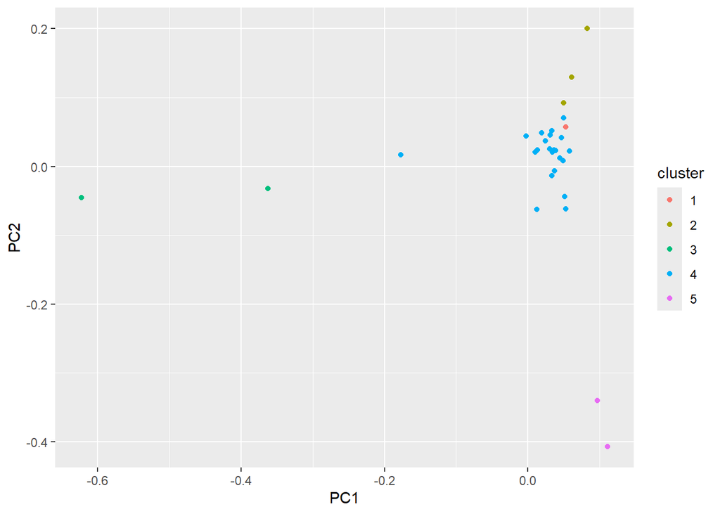

```r
# Follow this template to visualize the fill clusters

# clusters_pca_1_2 |>
#   ggplot() +
#   geom_point(aes(x = PC1,
#                  y = PC2,
#                  color = .cluster))

## Improve the plot by adding labels to the x, y axis
## and a title to explain the visualization to the
## marketing team
clusters_pca_1_2 <- customer_product_table |>
  select(bikeshop.name) |>
  bind_cols(pca_1_2) |>
  mutate(cluster = clusters) |>
  mutate(cluster = factor(x = cluster,
                          ordered = FALSE))

clusters_pca_1_2 |>
  ggplot() +
  geom_point(aes(x = PC1,
                 y = PC2,
                 color = cluster))
```